# FPCC2 - l2p2 - Uma analise bem maior

Wesley Brenno

O obejetivo da atividade é responder 4 perguntas propostas pela wikimedia na seleção realizada em 2016 para o cargo de analista de dados. São elas:

- Qual a taxa de clique geral diária? Como ela varia entre os grupos?
- Quais resultados as pessoas tendem a tentar primeiro? Como ela muda dia-a-dia?
- Qual é a nossa taxa com resultados zerados geral diária? Como ela varia entre os grupos?
- Considere a duração da sessão aproximadamente o tempo entre o primeiro evento e o último evento da sessão. Escolha uma variável do conjunto dos dados e descreva seu relacionamento com a duração da sessão. Visualize a relação.

### Preparação dos dados

Os dados originais fornecidos pela Wikimedia foram previamente tratados pelo professor e disponibilizado no arquivo data/search_data.csv.

Iremos ler estes dados e atribuir à variável buscas e adicionar uma variável para representar a data das sessões, ignorando o horário. Esta variável se chamará date.

```r
buscas = read_csv(here::here("data/search_data.csv")) %>%
    mutate(date = ymd_hms(session_start_timestamp))  %>%
    ungroup()
```

### Questão 1: Qual a taxa de clique geral diária? Como ela varia entre os grupos?

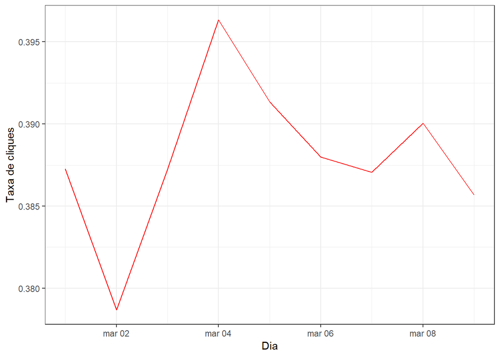

```r
buscas %>%
    filter(!(num_clicks > 0 && (is.na(first_click) | first_click <= results))) %>%
    mutate(date = round_date(date, unit = "day")) %>%
    group_by(date) %>%
    summarise(sessions_per_day = n_distinct(session_id), sessions_with_one_click = n_distinct(session_id[num_clicks > 0])) %>%
    ggplot(aes(x = date, y = sessions_with_one_click/sessions_per_day)) +
    geom_line(colour="red") +
    labs(x="Dia", y = "Taxa de cliques")
```

Podemos observar que a taxa de cliques varia entre 38% e 40%.

Observando por grupos, temos o seguinte resultado:

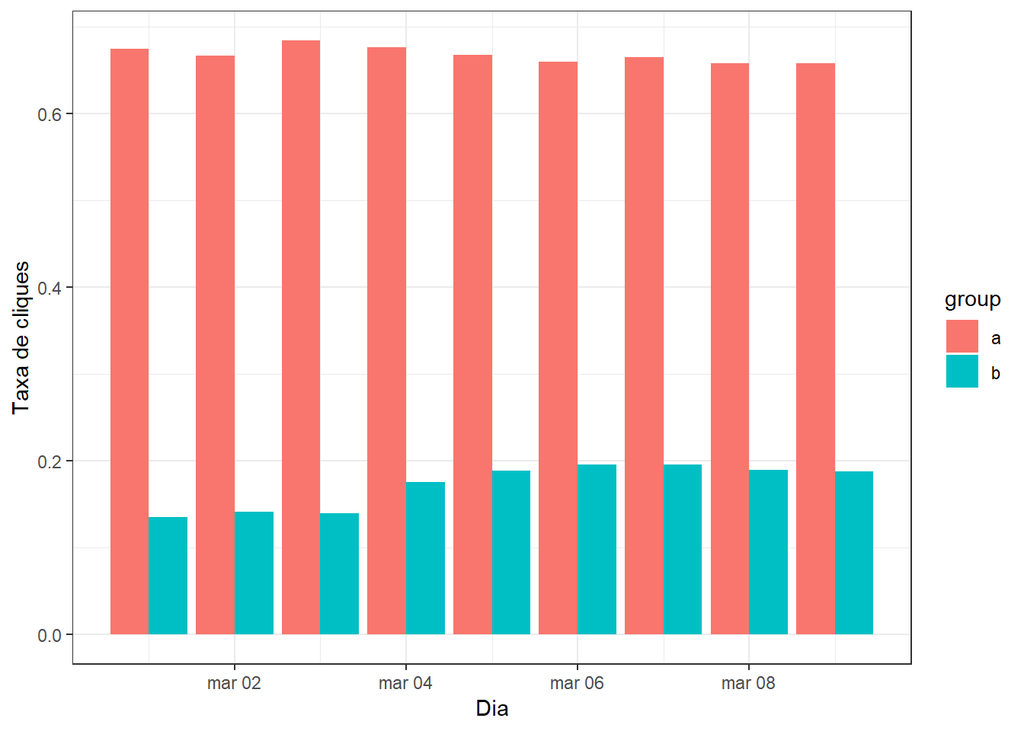

```r
buscas %>%
    mutate(date = round_date(date, unit = "day")) %>%
    group_by(date, group) %>%
    summarise(sessions_per_day = n_distinct(session_id), sessions_with_one_click = n_distinct(session_id[num_clicks > 0])) %>%
    ggplot(aes(x = date, y = sessions_with_one_click/sessions_per_day, fill=group)) +
    geom_bar(stat="identity", position=position_dodge()) +
    labs(x="Dia", y = "Taxa de cliques")
```

Onde percebe-se que o grupo “A” apresenta uma taxa de cliques diários muito maior que o grupo “B”, mas a variação diária de ambos os grupos não são tão expressivas. Aparentemente quando a taxa de cliques do grupo “A” aumenta, o do grupo “B” diminui, e vice-versa.

### Questão 2: Quais resultados as pessoas tendem a tentar primeiro? Como ela muda dia-a-dia?

Para responder essa pergunta, analisaremos a variável first_click, que indica o índice do resultado clicado na busca. Para começar, agrupamos os dados por first_click e realizamos a soma de registros para cada um dos índices. Temos o resultado a baixo.

```r
buscas %>%
    filter(!is.na(first_click))%>%
    mutate(date = round_date(date, unit = "day")) %>%
    group_by(first_click) %>%
    summarise(total_cliques = n())
```

| first_click | total_cliques |
| --- | --- |
| 1 | 21013 |
| 2 | 4705 |
| 3 | 2379 |
| 4 | 1297 |
| 5 | 820 |
| 6 | 574 |
| 7 | 396 |
| 8 | 270 |
| 9 | 225 |
| 10 | 196 |

[output cut: 179 more lines]

Fazendo uma análise rápida dos dados, é fácil perceber que após o índice 20, os resultados apresenta menos de 10 cliques, o que faz com que utilizar esses dados atrapalha na visualização dos dados, como podemos ver no histograma abaixo:

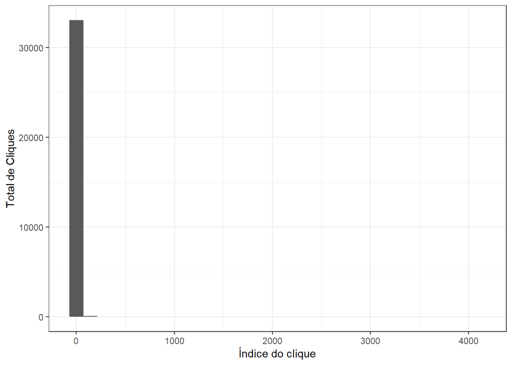

```r
buscas %>%
    filter(!is.na(first_click)) %>%
    group_by(first_click) %>%
    ggplot(aes(x = first_click)) +
    geom_histogram() +
    labs(x = "Índice do clique", y = "Total de Cliques")
```

Por isso, para obter uma visualização mais relevante dos dados, vamos considerar os dados para os índices antes do 20. Com essa restrição obtemos o seguinte resultado.

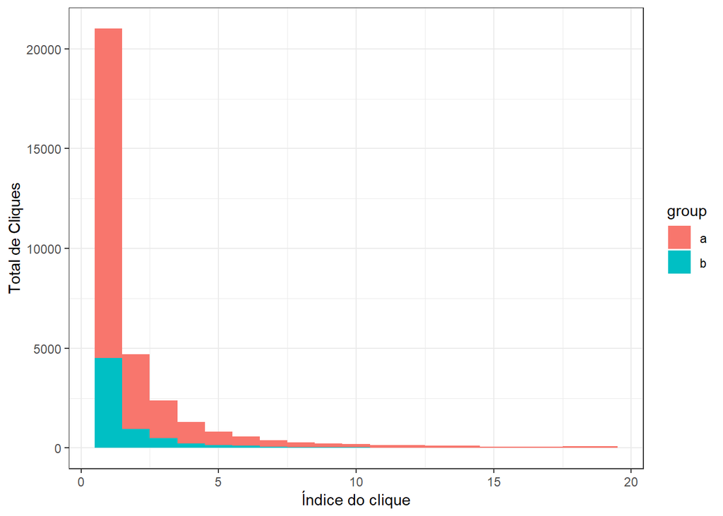

```r
buscas %>%
    filter(first_click < 20) %>%
    group_by(first_click, group) %>%
    ggplot(aes(x = first_click, fill=group)) +
    geom_histogram(binwidth = 1) +
    labs(x = "Índice do clique", y = "Total de Cliques")
```

Onde percebemos que a maior concentração de primeiros cliques esão entre os índices 1 e 5, para ambos os grupos. Podemos ver também que a quantidade des cliques do grupo B é consideravelmente menor que as do grupo A, o que já era esperado devido a diferença considerável entre a taxa de cliques de ambas, encontrada na análise da pergunta anterior

Gerando histogramas para cada dia, obtemos os seguintes resultados

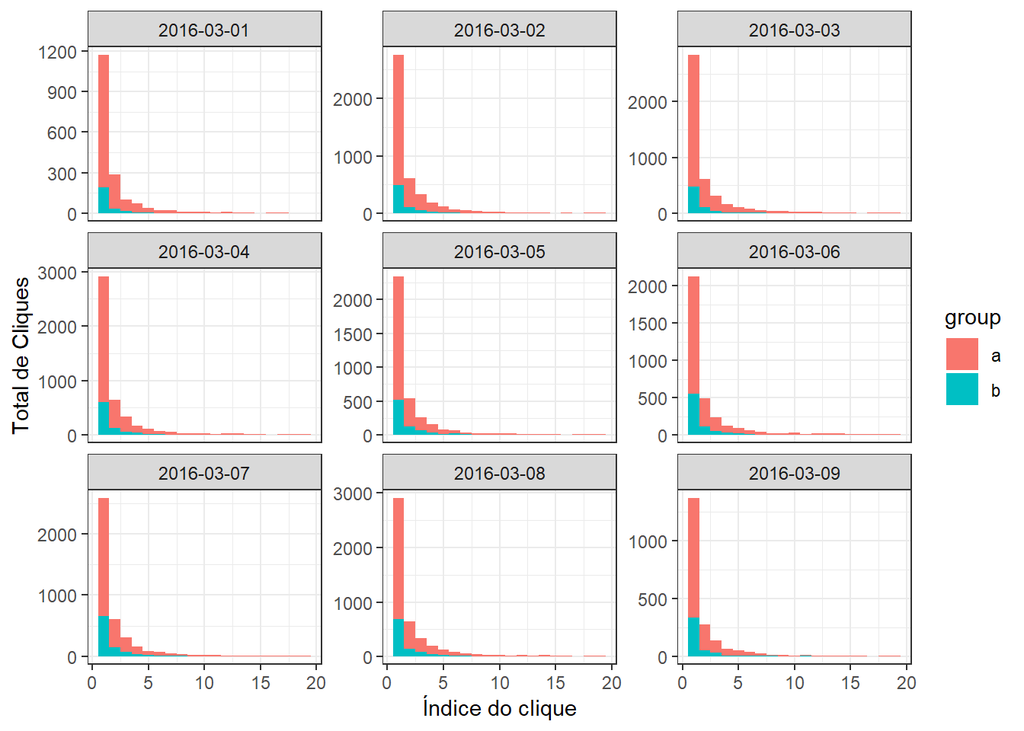

```r
buscas %>%
    filter(first_click < 20) %>%
    mutate(date = round_date(date, unit = "day")) %>%
    group_by(first_click, group, date) %>%
    ggplot(aes(x = first_click, fill=group)) +
    facet_wrap(~date, scales = "free_y") +
    geom_histogram(binwidth = 1) +
    labs(x = "Índice do clique", y = "Total de Cliques")
```

Onde observamos que não há diferença entre os dias da distribuição de cliques nos indíces. Assim, podemos afirmar que o comportamento dos usuários é semelhante independente dos dias, onde os mesmos tendem a clicar nos primeiros 5 resultados da busca.

### Questão 3: Qual é a nossa taxa com resultados zerados geral diária? Como ela varia entre os grupos?

A Wikimedia considera taxa com resultados zerados como a proporção de resultados que obtiveram 0 respostas nas pesquisas.Para o cálculo dessa taxa , usaremos a variável results. Começamos então eliminando os registros onde não há informação sobre os resultados, agrupamos por dia, somamos a quantiadade de resultados iguais a 0 e quantidade de resultados no geral, realizamos a proporção e obtemos o seguinte resultado:

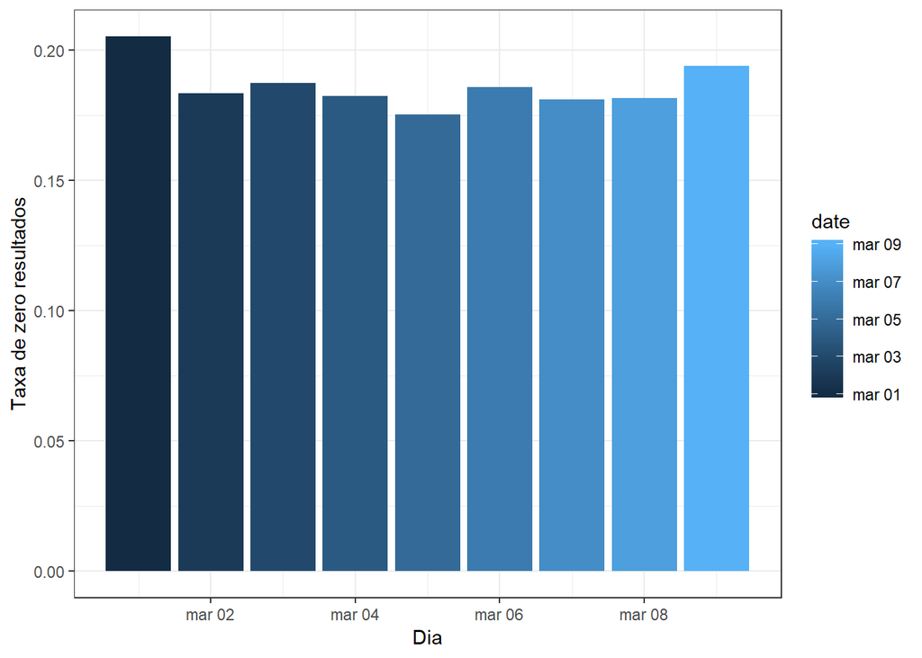

```r
buscas %>%
    filter(!is.na(results)) %>%
    mutate(date = round_date(date, unit = "day")) %>%
    group_by(date) %>%
    summarise(n_tota_search = length(results), zero_results = length(results[results == 0])) %>%
    ggplot(aes(x = date, y = zero_results / n_tota_search, fill=date)) +
    geom_bar(stat="identity", position=position_dodge()) +
    labs(x="Dia", y="Taxa de zero resultados")
```

Agrupando por grupo, e por dia e grupo temos o seguinte:

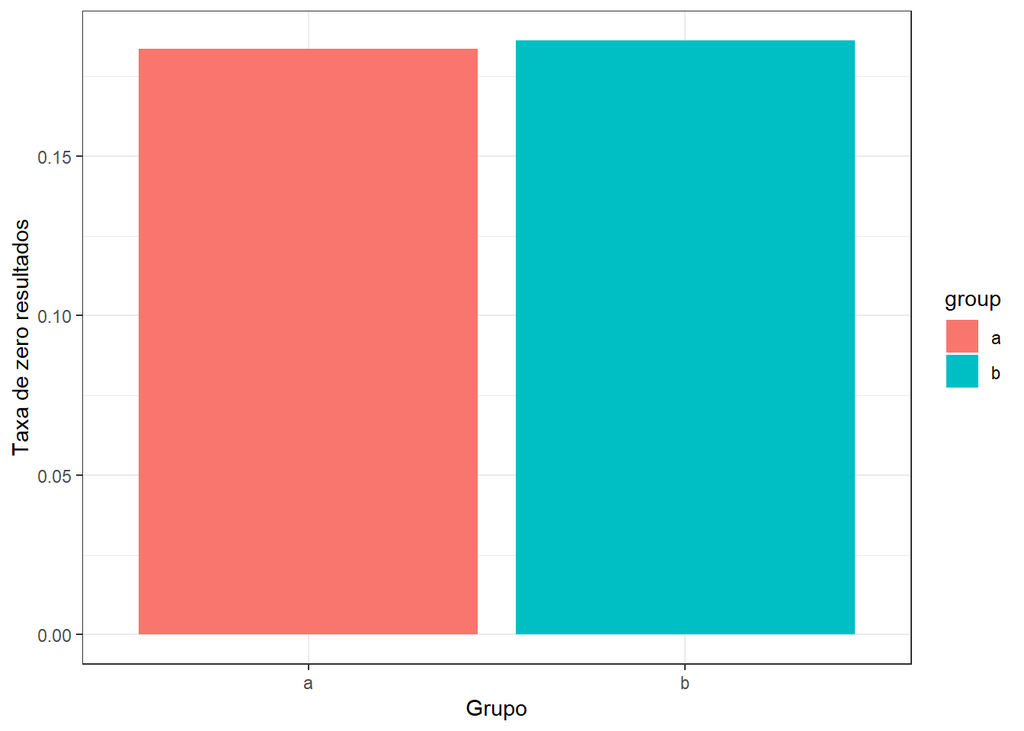

```r
buscas %>%
    filter(!is.na(results)) %>%
    mutate(date = round_date(date, unit = "day")) %>%
    group_by(group) %>%
    summarise(n_tota_search = length(results), zero_results = length(results[results == 0])) %>%
    ggplot(aes(x = group, y = zero_results / n_tota_search, fill=group)) +
    geom_bar(stat="identity", position=position_dodge()) +
    labs(x="Grupo", y="Taxa de zero resultados")
```

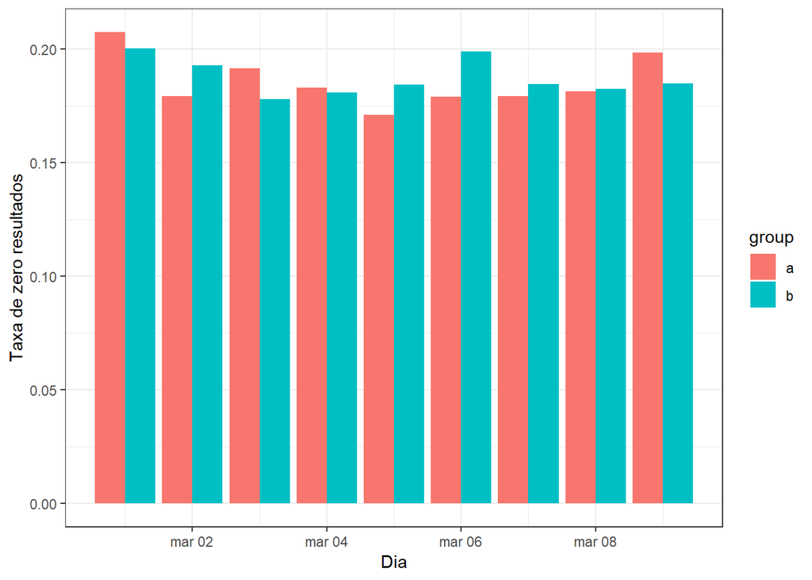

```r
buscas %>%
    filter(!is.na(results)) %>%
    mutate(date = round_date(date, unit = "day")) %>%
    group_by(date, group) %>%
    summarise(n_tota_search = length(results), zero_results = length(results[results == 0])) %>%
    ggplot(aes(x = date, y = zero_results / n_tota_search, fill=group)) +
    geom_bar(stat="identity", position=position_dodge()) +
    labs(x="Dia", y="Taxa de zero resultados")
```

Onde podemos ver que os grupos possuem comportamento parecidos.

### Questão 4: Considere a duração da sessão aproximadamente o tempo entre o primeiro evento e o último evento da sessão. Escolha uma variável do conjunto dos dados e descreva seu relacionamento com a duração da sessão. Visualize a relação.

Escolheremos a variável first_click para vermos a relação entre ela e a duração da sessão, ou seja, veremos se o fato de clicar nos primeiros índices (ou seja encontrar nos primeiros índices o que se busca) diminui o tempo das sessões, e vice-versa.

Relacionando as duas variáveis obtemos os seguintes resultados:

[figure not shown]

```r
buscas %>%
    filter(!is.na(first_click) & !is.na(session_length)) %>%
    ggplot(aes(x = first_click, y = session_length)) +
    geom_point() +
    geom_jitter(alpha = 0.25) +
    scale_y_log10() +
    labs(x = "Tempo da Sessão", y = "Indice do primeiro clique")
```

Onde visualmente podemos dizer que não enxergamos uma correlação entre as variáveis. Como sabemos que a maioria dos registros do first_click está concentrado em índices menores que 20, vamos realizar a visualização dos dados restrigindo-os a esse limite. Assim obtemos a seguinte visualização:

[figure not shown]

```r
buscas %>%
    filter(!is.na(first_click) & !is.na(session_length) & first_click < 20) %>%
    ggplot(aes(x = first_click, y  = session_length)) +
    geom_point() +
    geom_jitter(alpha = 0.25) +
    scale_y_log10() +
    labs(x = "Tempo da Sessão", y = "Indice do primeiro clique")
```

Ainda assim, não conseguimos visualizar uma correlação entre as variáveis.

```r
buscas %>%
    filter(!is.na(first_click) & !is.na(session_length)) %>%
    summarise(
        pearson = cor(session_length, first_click, method = "pearson"),
        spearman = cor(session_length, first_click, method = "pearson")
    )
```

| pearson | spearman |
| --- | --- |
| 0.003917733 | 0.003917733 |

Dividindo por grupos, também obtemos os mesmos resultados.

[figure not shown]

```r
buscas %>%
    filter(!is.na(first_click) & !is.na(session_length) & first_click < 20 & group == "a") %>%
    ggplot(aes(x = first_click, y  = session_length)) +
    geom_point() +
    geom_jitter(alpha = 0.25) +
    scale_y_log10() +
    labs(x = "Tempo da Sessão", y = "Indice do primeiro clique" , title = "Grupo a")
```

[figure not shown]

```r
buscas %>%
    filter(!is.na(first_click) & !is.na(session_length) & first_click < 20 & group == "b") %>%
    ggplot(aes(x = first_click, y  = session_length)) +
    geom_point() +
    geom_jitter(alpha = 0.25) +
    scale_y_log10() +
    labs(x = "Tempo da Sessão", y = "Indice do primeiro clique" , title = "Grupo b")
```

```r
buscas %>%
    filter(!is.na(first_click) & !is.na(session_length) & group == "a") %>%
    summarise(
        pearson = cor(session_length, first_click, method = "pearson"),
        spearman = cor(session_length, first_click, method = "pearson")
    )
```

| pearson | spearman |
| --- | --- |
| 0.003525609 | 0.003525609 |

```r
buscas %>%
    filter(!is.na(first_click) & !is.na(session_length) & group == "b") %>%
    summarise(
        pearson = cor(session_length, first_click, method = "pearson"),
        spearman = cor(session_length, first_click, method = "pearson")
    )
```

| pearson | spearman |
| --- | --- |
| 0.0005560506 | 0.0005560506 |